# Script for the Machine Learning Predictions

Adrien M. Ratsimbaharison

March 17, 2019

## The six steps in the machine learning predictions:

These steps generally follow the steps suggested by different machine learning practitioners and instructors, including Lantz (2015), Pierobon (2018), and Leek, Peng, & Caffo (2018).

1. Defining the problem
2. Exploring the Data
3. Preparing the data: data randomization and partition
4. Modeling and predicting with classification
5. Modeling and predicting with regression
6. Conclusion

```r
#  Loading the required packages:
library(caret)
library(dplyr)
library(ggplot2)
library(readr)
library(rattle)
```

### Step 1: Defining the problem

When performing machine learning techniques, it is always a good idea to define exactly What you are trying to predict. In our case, we are trying to predict:

1. the classification of countries either as “stable” (with stability scores greater than 0) or as “unstable” (with stability scores less than 0), and
2. the stability scores of countries based on some predictors.

In terms of machine learning, we are dealing in this case with a multivariate supervised machine learning problem in which we have to predict a binary and multi-class outcome (thus we will use classification techniques) and a numeric outcome (thus we will use a mutliple regression technique).

### Step 2: Reading and exploring the Data in r

Our data were downloaded from different sources and merged in a single data frame (See script on downloading quantitative data for the information on how the data were collected and manipulated).

We just need here to read the data into r and explore the features.

```r
# reading the data into r

WGIdevRegimeType <- read.csv("WGIdevRegimeType.csv")

# looking at the different types of variables and correcting their classes

WGIdevRegimeType$stabilityDummy <- as.factor(WGIdevRegimeType$stabilityDummy)

glimpse(WGIdevRegimeType)
```

```
## Observations: 4,846
## Variables: 46
## $ X                       <int> 1, 2, 3, 4, 5, 6, 7, 8, 9, 10, 11, 12,...
## $ country                 <fct> Aruba, Aruba, Aruba, Aruba, Aruba, Aru...
## $ M49Code                 <int> 533, 533, 533, 533, 533, 533, 533, 533...
## $ iso2c                   <fct> AW, AW, AW, AW, AW, AW, AW, AW, AW, AW...
## $ iso3c                   <fct> ABW, ABW, ABW, ABW, ABW, ABW, ABW, ABW...
## $ date                    <int> 1996, 1998, 2000, 2002, 2003, 2004, 20...
## $ stability               <dbl> 1.0233479, 0.9895858, 0.9895858, 0.989...
## $ stabilityDummy          <fct> 1, 1, 1, 1, 1, 1, 1, 1, 1, 1, 1, 1, 1,...
## $ stabilityCategory       <fct> Highly Stable, Moderately Stable, Mode...
## $ corruptionControl       <dbl> 1.5427264, 1.5964284, 1.6577593, 1.228...
## $ governmentEffectiveness <dbl> 1.771766543, 1.978873014, 2.042146683,...
## $ regulatoryQuality       <dbl> 1.7832654, 1.7777016, 1.8493328, 1.638...
## $ ruleOfLaw               <dbl> 0.8091406, 0.9085175, 0.8622218, 0.858...
```

[output cut: 33 more lines]

Before preparing the data for the modeling, we need to take a look at the target variables: stabilityDummy and stability.

```r
# summary statistics of the target variables
table(WGIdevRegimeType$stabilityDummy)
```

```
##
##    0    1
## 1778 3068
```

```r
summary(WGIdevRegimeType$stability)
```

```
##    Min. 1st Qu.  Median    Mean 3rd Qu.    Max.
## -3.3149 -0.4475  0.4544  0.2265  1.0807  1.9651
```

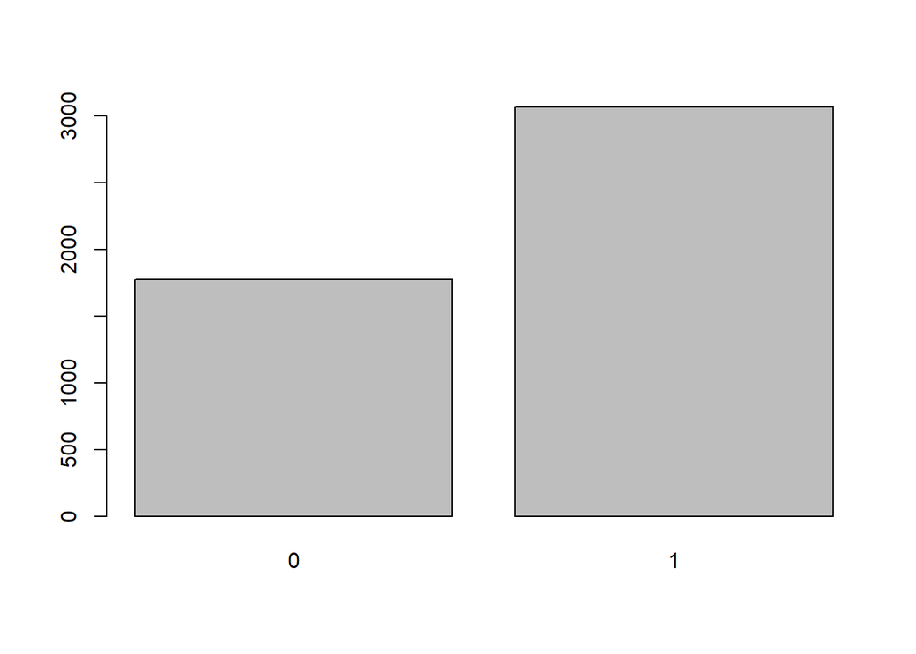

```r
# plotting the target variables

barplot(table(WGIdevRegimeType$stabilityDummy))
```

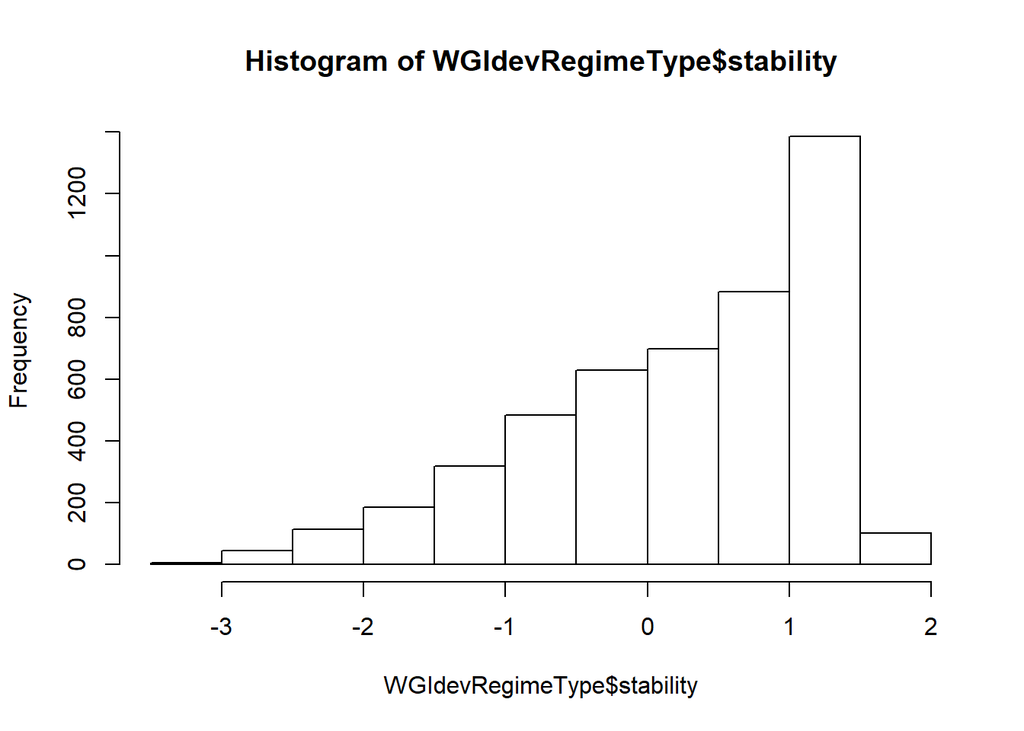

```r
hist(WGIdevRegimeType$stability)
```

We need also to take a look at the summary statistics of the other variables of interest, paying attention to the existence of NAs, outliers, and zero variances.

```r
WGIdevRegimeTypeSummary <- select(WGIdevRegimeType, stability, stabilityDummy, stabilityCategory, corruptionControl, governmentEffectiveness, regulatoryQuality, ruleOfLaw, voiceAndAccountability, GNIperCapita, devCategory, GDPannualGrowthRate, HDI, GINI, povertyHeadCount, polityScore, polityCategory, politicalChange, democ, autoc, durable, xrreg, xrcomp, xropen, xconst, parreg, parcomp, exrec, exconst, polcomp, pr, cl, sum, mean, status, inverse_pr, inverse_cl, inverse_mean, politicalChangeFH, region, subregion)

summary(WGIdevRegimeTypeSummary)
```

```
##    stability       stabilityDummy           stabilityCategory
##  Min.   :-3.3149   0:1778         Highly Stable      :1498
##  1st Qu.:-0.4475   1:3068         Highly Unstable    : 667
##  Median : 0.4544                  Moderately Stable  :1570
##  Mean   : 0.2265                  Moderately Unstable:1111
##  3rd Qu.: 1.0807
##  Max.   : 1.9651
##
##  corruptionControl governmentEffectiveness regulatoryQuality
##  Min.   :-1.8687   Min.   :-2.4784         Min.   :-2.6450
##  1st Qu.:-0.6352   1st Qu.:-0.6125         1st Qu.:-0.5432
##  Median : 0.1665   Median : 0.2024         Median : 0.2839
##  Mean   : 0.2928   Mean   : 0.3317         Mean   : 0.2879
##  3rd Qu.: 1.3334   3rd Qu.: 1.4710         3rd Qu.: 1.3565
##  Max.   : 2.4700   Max.   : 2.4370         Max.   : 2.2605
##
##    ruleOfLaw       voiceAndAccountability  GNIperCapita
##  Min.   :-2.6064   Min.   :-2.3134        Min.   :   204.9
##  1st Qu.:-0.6593   1st Qu.:-0.5750        1st Qu.:  1295.9
##  Median : 0.2753   Median : 0.4306        Median :  4000.5
##  Mean   : 0.2204   Mean   : 0.2189        Mean   : 11621.9
##  3rd Qu.: 1.0816   3rd Qu.: 1.1133        3rd Qu.: 17276.4
##  Max.   : 2.1003   Max.   : 1.8010        Max.   :119043.8
##
##               devCategory   GDPannualGrowthRate      HDI
##  High Income        :1452   Min.   :-62.076     Min.   :0.2350
##  Low Income         :1007   1st Qu.:  1.642     1st Qu.:0.5693
##  Lower Middle Income:1439   Median :  3.770     Median :0.6960
##  Upper Middle Income: 948   Mean   :  3.856     Mean   :0.6746
##                             3rd Qu.:  5.978     3rd Qu.:0.7930
##                             Max.   :149.973     Max.   :0.9530
##
##       GINI       povertyHeadCount  polityScore        polityCategory
##  Min.   :16.20   Min.   : 0.0     Min.   :-10.000   Anocracy :1159
##  1st Qu.:37.30   1st Qu.: 1.3     1st Qu.:  5.000   Autocracy: 468
##  Median :42.10   Median : 5.8     Median :  9.000   Democracy:3219
##  Mean   :41.21   Mean   :14.4     Mean   :  5.869
##  3rd Qu.:45.00   3rd Qu.:21.0     3rd Qu.: 10.000
##  Max.   :65.80   Max.   :94.1     Max.   : 10.000
##
```

[output cut: 41 more lines]

```
##  Min.   :1.000   Min.   :1.000   autocratization: 242    Africa  :1031
##  1st Qu.:4.000   1st Qu.:4.000   democratization: 296    Americas: 950
##  Median :6.000   Median :6.000   no change      :4308    Asia    : 981
##  Mean   :5.269   Mean   :5.248                           Europe  :1320
##  3rd Qu.:7.000   3rd Qu.:7.000                           Oceania : 564
##  Max.   :7.000   Max.   :7.000
##
##            subregion
##  Caribbean      : 467
##  Western Europe : 371
##  Eastern Africa : 370
##  Western Asia   : 351
##  Micronesia     : 339
##  Southern Europe: 322
##  (Other)        :2626
```

From the summary statistics of the other variables, we can see that, among the Polity IV variables, there are some extreme values of -66 (for interruption periods), -77 (for interregnum), and -88 (for transition periods), which are known as “standardized authority codes” (See Marshall, M. G., Gurr, T. R., & Jaggers, K., 2018). Since there is no commonly agreed procedure on how to handle these extreme values among scholars (See Plümper, T., & Neumayer, E., 2010), we decided to remove them from our data, because they may falsify our results.

```r
# Removing the interruption periods (-66), interregnum periods (-77), and transitional periods (-88)

WGIdevRegimeType <- filter(WGIdevRegimeType, democ != -88 & democ != -77 &  democ != -66)

summary(WGIdevRegimeType)
```

```
##        X                       country        M49Code          iso2c
##  Min.   :   1   Sudan              :  23   Min.   :  4.0   FI     : 352
##  1st Qu.:1208   Albania            :  22   1st Qu.:218.0   LI     : 138
##  Median :2433   Algeria            :  22   Median :414.0   SS     : 123
##  Mean   :2428   Andorra            :  22   Mean   :415.6   TW     :  73
##  3rd Qu.:3646   Antigua and Barbuda:  22   3rd Qu.:624.0   NZ     :  67
##  Max.   :4846   Argentina          :  22   Max.   :894.0   CK     :  48
##                 (Other)            :4614                   (Other):3946
##      iso3c           date        stability       stabilityDummy
##  FIN    : 362   Min.   :1996   Min.   :-2.9741   0:1682
##  LIE    : 143   1st Qu.:2001   1st Qu.:-0.3903   1:3065
##  SSD    : 116   Median :2007   Median : 0.4939
##  NZL    :  69   Mean   :2007   Mean   : 0.2708
##  NLD    :  42   3rd Qu.:2012   3rd Qu.: 1.0898
##  GRL    :  36   Max.   :2017   Max.   : 1.9651
##  (Other):3979
##            stabilityCategory corruptionControl governmentEffectiveness
##  Highly Stable      :1498    Min.   :-1.8257   Min.   :-2.4459
##  Highly Unstable    : 592    1st Qu.:-0.5993   1st Qu.:-0.5802
##  Moderately Stable  :1567    Median : 0.2181   Median : 0.2478
##  Moderately Unstable:1090    Mean   : 0.3243   Mean   : 0.3686
##                              3rd Qu.: 1.3499   3rd Qu.: 1.5083
##                              Max.   : 2.4700   Max.   : 2.4370
##
##  regulatoryQuality   ruleOfLaw       voiceAndAccountability
##  Min.   :-2.5296   Min.   :-2.4234   Min.   :-2.3134
##  1st Qu.:-0.5105   1st Qu.:-0.6180   1st Qu.:-0.5104
##  Median : 0.3194   Median : 0.3376   Median : 0.4678
##  Mean   : 0.3235   Mean   : 0.2555   Mean   : 0.2479
##  3rd Qu.: 1.3565   3rd Qu.: 1.1024   3rd Qu.: 1.1133
##  Max.   : 2.2605   Max.   : 2.1003   Max.   : 1.8010
##
##   GNIperCapita                   devCategory   GDPannualGrowthRate
##  Min.   :   204.9   High Income        :1452   Min.   :-52.428
##  1st Qu.:  1351.3   Low Income         : 941   1st Qu.:  1.665
##  Median :  4162.2   Lower Middle Income:1415   Median :  3.774
##  Mean   : 11831.4   Upper Middle Income: 939   Mean   :  3.878
##  3rd Qu.: 17810.4                              3rd Qu.:  5.963
##  Max.   :119043.8                              Max.   :149.973
##
```

[output cut: 49 more lines]

```
##  Min.   :1.000   Min.   :1.000   autocratization: 224    Africa  : 977
##  1st Qu.:4.000   1st Qu.:4.000   democratization: 274    Americas: 940
##  Median :6.000   Median :6.000   no change      :4249    Asia    : 950
##  Mean   :5.328   Mean   :5.308                           Europe  :1320
##  3rd Qu.:7.000   3rd Qu.:7.000                           Oceania : 560
##  Max.   :7.000   Max.   :7.000
##
##            subregion
##  Caribbean      : 458
##  Western Europe : 371
##  Eastern Africa : 349
##  Micronesia     : 339
##  Western Asia   : 334
##  Southern Europe: 322
##  (Other)        :2574
```

```r
dim(WGIdevRegimeType)
```

```
## [1] 4747   46
```

### Step 3: Preparing the data: data randomization and feature selection

The data were arranged in a country-year format. Therefore, it is a good idea to randoming the rows before partitioning the dataset

```r
# Randomizing the dataset
set.seed(112)
rows <- sample(nrow(WGIdevRegimeType))
WGIdevRegimeTypeRand <- WGIdevRegimeType[rows, ]
```

```r
# Selecting the variables to be included in the classification model. We need to remove the political stability score (stability) and stability category (stabilityCategory) from this dataset.

WGIdevRegimeTypeRandClass <- select(WGIdevRegimeTypeRand, stabilityDummy, corruptionControl, governmentEffectiveness, regulatoryQuality, ruleOfLaw, voiceAndAccountability, GNIperCapita, GDPannualGrowthRate, HDI, GINI, povertyHeadCount, polityScore, polityCategory, politicalChange, democ, autoc, durable, xrreg, xrcomp, xropen, xconst, parreg, parcomp, exrec, exconst, polcomp, pr, cl, sum, mean, status, inverse_pr, inverse_cl, inverse_mean, politicalChangeFH, region, subregion)
```

```r
# Selecting the variables to be included in the regression model. We need to remove the stability dummy (stabilityDummy) and stability category (stabilityCategory) from this dataset.

WGIdevRegimeTypeRandReg <- select(WGIdevRegimeTypeRand, stability, corruptionControl, governmentEffectiveness, regulatoryQuality, ruleOfLaw, voiceAndAccountability, GNIperCapita, GDPannualGrowthRate, HDI, GINI, povertyHeadCount, polityScore, polityCategory, politicalChange, democ, autoc, durable, xrreg, xrcomp, xropen, xconst, parreg, parcomp, exrec, exconst, polcomp, pr, cl, sum, mean, status, inverse_pr, inverse_cl, inverse_mean, politicalChangeFH, region, subregion)
```

### Step 4: Modeling and predicting with classification

```r
# Partitionning the dataset into training set and testing set for the classification model
set.seed(123)
inTrain1 <- createDataPartition(y = WGIdevRegimeTypeRandClass$stabilityDummy, p = .75, list = FALSE)
training1 <- WGIdevRegimeTypeRandClass[inTrain1,]
testing1 <- WGIdevRegimeTypeRandClass[-inTrain1,]
```

```r
# Training the classification model

classModel <- train(stabilityDummy ~ ., method = "rpart", data = training1,
                    trControl = trainControl(method = "cv", number = 5,
                                           verboseIter = TRUE),
                    preProcess = c("zv", "nzv", "center", "scale")
                    )
print(classModel$finalModel)
```

```
## n= 3561
##
## node), split, n, loss, yval, (yprob)
##       * denotes terminal node
##
##  1) root 3561 1262 1 (0.35439483 0.64560517)
##    2) ruleOfLaw< -0.4129169 1391  314 0 (0.77426312 0.22573688) *
##    3) ruleOfLaw>=-0.4129169 2170  185 1 (0.08525346 0.91474654)
##      6) cl>=-0.08551258 327  137 1 (0.41896024 0.58103976)
##       12) corruptionControl< -0.04627442 196   80 0 (0.59183673 0.40816327) *
##       13) corruptionControl>=-0.04627442 131   21 1 (0.16030534 0.83969466) *
##      7) cl< -0.08551258 1843   48 1 (0.02604449 0.97395551) *
```

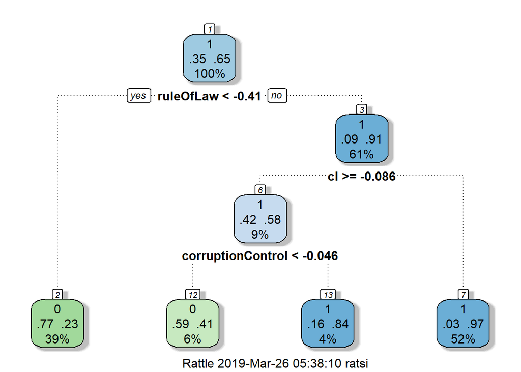

```r
# Plotting the classification model
fancyRpartPlot(classModel$finalModel)
```

```r
# Making prediction and assessing the model performance

classPred <- predict(classModel, testing1)

confusionMatrix(classPred, testing1$stabilityDummy)
```

```
## Confusion Matrix and Statistics
##
##           Reference
## Prediction   0   1
##          0 394 135
##          1  26 631
##
##                Accuracy : 0.8642
##                  95% CI : (0.8434, 0.8832)
##     No Information Rate : 0.6459
##     P-Value [Acc > NIR] : < 2.2e-16
##
##                   Kappa : 0.7197
##  Mcnemar's Test P-Value : < 2.2e-16
##
##             Sensitivity : 0.9381
##             Specificity : 0.8238
##          Pos Pred Value : 0.7448
##          Neg Pred Value : 0.9604
##              Prevalence : 0.3541
##          Detection Rate : 0.3322
##    Detection Prevalence : 0.4460
##       Balanced Accuracy : 0.8809
##
##        'Positive' Class : 0
##
```

### Step 5: Modeling and predicting with regression

```r
# Partitionning the dataset into training set and testing set for the regression model
set.seed(234)
inTrain2 <- createDataPartition(y = WGIdevRegimeTypeRandReg$stability, p = .75, list = FALSE)
training2 <- WGIdevRegimeTypeRandReg[inTrain2,]
testing2 <- WGIdevRegimeTypeRandReg[-inTrain2,]
dim(training2)
```

```
## [1] 3563   37
```

```r
dim(testing2)
```

```
## [1] 1184   37
```

```r
# Training the regression model

regModel <- train(stability ~ ., method = "glm", data = training2,
                  trControl = trainControl(method = "cv", number = 5,
                                           verboseIter = TRUE),
                  preProcess = c("zv", "nzv", "center", "scale", "pca")
                  )
regFinalModel <- regModel$finalModel

print(regModel)
```

```
## Generalized Linear Model
##
## 3563 samples
##   36 predictor
##
## Pre-processing: centered (48), scaled (48), principal component
##  signal extraction (48), remove (15)
## Resampling: Cross-Validated (5 fold)
## Summary of sample sizes: 2851, 2851, 2851, 2850, 2849
## Resampling results:
##
##   RMSE       Rsquared   MAE
##   0.5108481  0.7221264  0.3855061
```

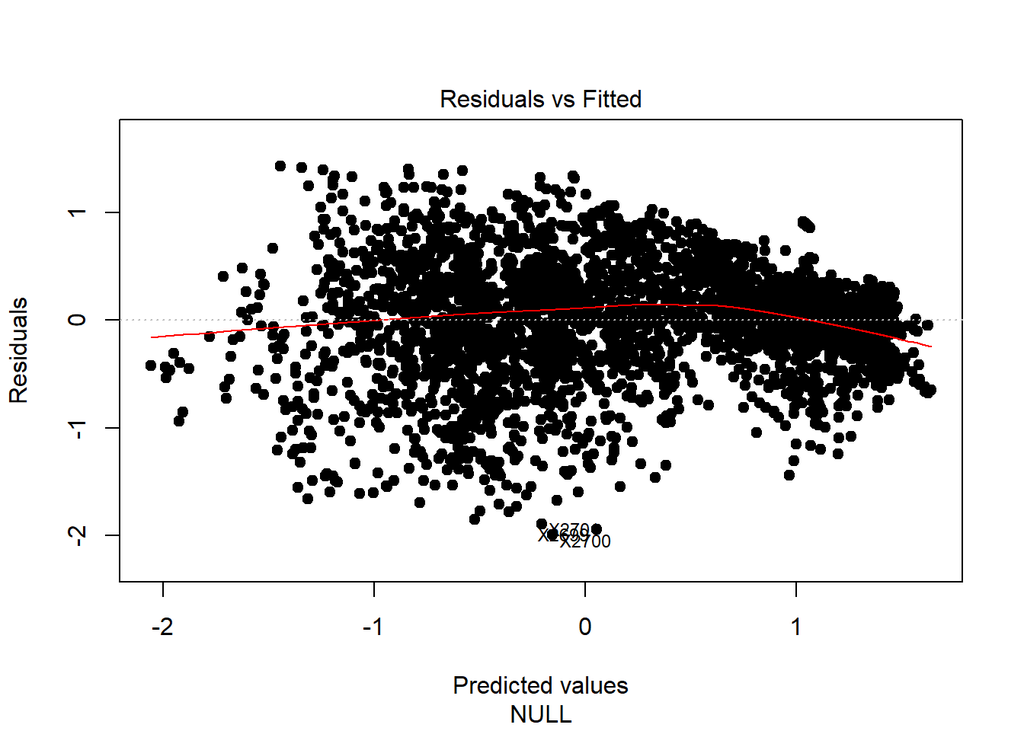

```r
# Regression model diagnostics

plot(regFinalModel, 1, pch = 19)
```

```r
# Making prediction and assessing the model performance

regPred <- predict(regModel, testing2)

postResample(pred = regPred, obs = testing2$stability)
```

```
##      RMSE  Rsquared       MAE
## 0.5044487 0.7318404 0.3813083
```

### Step 6: Conclusion